# Following up on species distribution models: a quick guide using R

A. Marcia Barbosa, CIBIO/InBIO - University of Evora (Portugal), barbosa@uevora.pt

(updated May 5, 2018)

**This guide is a companion to the following article, which you should cite if you use it:**

#### *Barbosa A.M., Munoz A.R., Puerto M.A. & Real R. (in review) Following up on species distribution models: checking predictions against data of the future*

The basic idea is to compare the performance of a species distribution model against the data that were used for building it (training data), and against data that were observed afterwards (test data), to check how predictions actually match further observations. The procedure is meant for models based on a **binary response** and a **logit link**, providing a **probability output**.

Start by (installing and) loading package *modEvA* for model evaluation and analysis:

```r
if (!require(modEvA)) install.packages("modEvA")
library(modEvA)
```

You’ll need a table with one observation/site/locality per line and at least **3 columns** containing, respectively, your **predicted probability** values, your **modelled data** (with 1 for presences, 0 for absences, and NA for observations not included in the model), and the **test data** observed at localities for which predictions are also available (NA where not available). Import your table to R (you can search for “R import data” on the internet).

For our examples, we’ll use a sample dataset that comes with the *modEvA* package. We’ll take the recorded presence-absence and predicted presence probability for one species (for example, *Ktropi*), and add a *fake* new presence-absence set, **simulating a random expansion** in the species’ distribution area, to use as model test data (you don’t need to run the following block of code if you have your own observed and predicted data in R):

```r
mydata <- data.frame(train = rotif.mods$models$Ktropi$y, pred = rotif.mods$models$Ktropi$fitted.values, test = rotif.mods$models$Ktropi$y)
set.seed(123)
mydata$test[sample(which(mydata$train == 0), 20)] <- 1
```

Take a look at the first rows of the dataset, to check that everything looks right:

```r
head(mydata)
```

```
##   train      pred test
## 1     0 0.0267022    0
## 2     1 0.6494431    1
## 3     1 0.6639190    1
## 4     1 0.3359397    1
## 5     0 0.3678857    0
## 6     1 0.3891151    1
```

So, our sample dataframe is called *mydata*, the column containing the predicted probability values is called *pred*, and the columns with the observed data before and after modelling (training and test data, respectively) are called *train* and *test*.

To confirm that your *train*ing data are indeed exactly the same that were used to get your *pred*icted data (i.e., including all sites that were modelled and excluding all sites that were not), check that they add up to the same value:

```r
with(mydata, all.equal(sum(train, na.rm = TRUE), sum(pred, na.rm = TRUE)))
```

```
## [1] TRUE
```

To quantify the lost, gained and maintained occurrences from the training to the test data, you can use the *fuzzyRangeChange* function of the *fuzzySim* package. This package is not yet on CRAN, but you can install it from R-Forge:

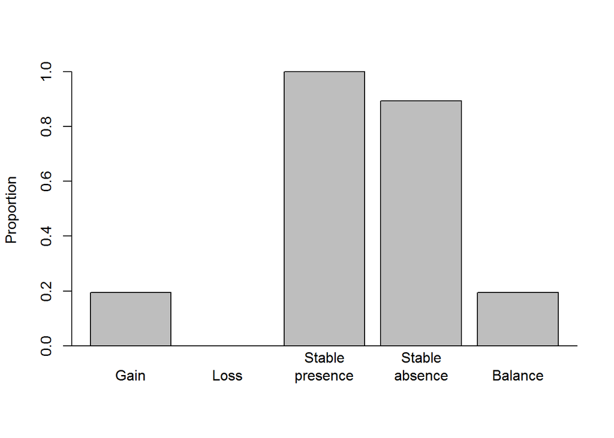

```r
if (!require(fuzzySim)) install.packages("fuzzySim", repos = "http://R-Forge.R-project.org")
library(fuzzySim)
with(mydata, fuzzyRangeChange(train, test, ylab = "Proportion"))
```

You can also get boxplots of the predicted values for the gained presences (as our *Ktropi* species expanded) versus the stable absences, across the study area (in white) or in the vicinity of training presences (in grey). For this, you can first calculate distance to training presences with the *distPres* function of the *fuzzySim* package (run `help(distPres)` for details), and define a distance threshold within which to consider the vicinity of presences:

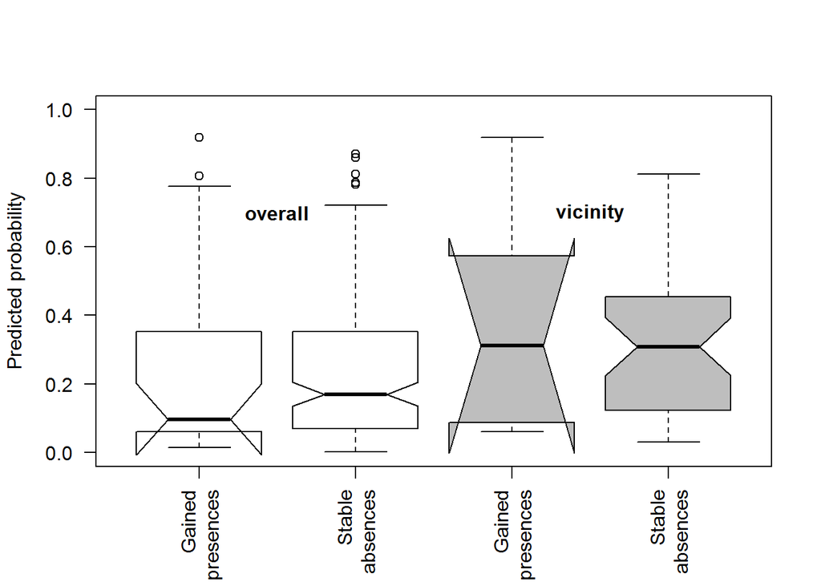

```r
data(rotif.env)  # load sample dataset that contains spatial coordinates of occurrence data
mydata <- data.frame(mydata, distPres(data = rotif.env, sp.cols = "Ktropi", coord.cols = c("Longitude", "Latitude"), inv = FALSE))  # add distance to mydata
head(mydata)  # distance column is named "Ktropi_D"
vicinity_thresh <- 5  # mind that these coordinates are in degrees; choose appropriate value for your data
with(mydata, boxplot(pred[train == 0 & test == 1], # gained presences
                     pred[train == 0 & test == 0], # stable absences
                     pred[train == 0 & test == 1 & Ktropi_D < vicinity_thresh],  # gained presences
                     pred[train == 0 & test == 0 & Ktropi_D < vicinity_thresh],  # stable absences
                     names = rep(c("Gained\npresences", "Stable\nabsences"), 2),
                     col = c(rep("white", 2), rep("grey", 2)),
                     las = 2, notch = TRUE, ylab = "Predicted probability", ylim = c(0, 1)))
text(1.5, 0.7, "overall", font = 2)
text(3.5, 0.7, "vicinity", font = 2)
```

You can thus check if the new presences actually appeared at sites with higher predicted values.

Now let’s evaluate model predictions against both the training and the test data. You can start by checking out the **ROC curve** and the area under it in each case (run `help(AUC)` for more details):

```r
auc_train <- with(mydata, AUC(obs = train, pred = pred))
```

```r
auc_test <- with(mydata, AUC(obs = test, pred = pred))
```

You can calculate several measures of **classification performance** (run `modEvAmethods("threshMeasures")` for a list of available measures). Note that for these you need to define a **threshold** or cut-off value above which to consider that the model predicts the species to be present rather than absent. For presence probability models, species **prevalence** (proportion of presences) can be a good option, and that’s what we’ll use below; but see *Details* in `help(threshMeasures)` for further options.

```r
cutoff <- "preval"
classif_meas <- c("CCR", "Sensitivity", "Specificity", "TSS", "kappa")
classif_train <- with(mydata, threshMeasures(obs = train, pred = pred, thresh = cutoff, measures = classif_meas))
```

```r
classif_test <- with(mydata, threshMeasures(obs = test, pred = pred, thresh = cutoff, measures = classif_meas))
```

```r
classif <- data.frame(train = classif_train$ThreshMeasures, test = classif_test$ThreshMeasures)
classif
```

[output not shown]

You can also check out **misclassification** and **model equilibrium** with the measures proposed in [this paper](http://onlinelibrary.wiley.com/doi/10.1111/ddi.12100/abstract):

```r
misclassif_meas <- c("UPR", "OPR", "PPI", "PAI")
misclass_train <- with(mydata, threshMeasures(obs = train, pred = pred, thresh = cutoff, measures = misclassif_meas))
```

```r
misclass_test <- with(mydata, threshMeasures(obs = test, pred = pred, thresh = cutoff, measures = misclassif_meas))
```

```r
misclass <- data.frame(train = misclass_train$ThreshMeasures, test = misclass_test$ThreshMeasures)
misclass
```

[output not shown]

Another important aspect of model evaluation is **calibration or reliability**. You can analyse model calibration with **Miller’s calibration line**. For the training data (if your *train*ing data are actually the same that were used for obtaining your *pred*icted values), this line should be exactly over the reference diagonal, with slope=1 and intercept=0. Run the following code and look at the results that appear in your R console and in your plotting window:

```r
miller_train <- with(mydata, MillerCalib(obs = train, pred = pred))
```

You can now look at Miller’s calibration line when the model is faced with the test data. A well-calibrated model should yield a slope near 1, while the intercept is less important; run `help(MillerCalib)` for more details.

```r
miller_test <- with(mydata, MillerCalib(obs = test, pred = pred))
```

You can also quantify the **explanatory or predictive power** of the model, with the **explained deviance** (D-squared) and several **pseudo R-squared** measures (see `help(Dsquared)` and `help(RsqGLM)` for further info):

```r
dsq_train <- with(mydata, Dsquared(obs = train, pred = pred, family = "binomial"))
dsq_test <- with(mydata, Dsquared(obs = test, pred = pred, family = "binomial"))
rsq_train <- with(mydata, RsqGLM(obs = train, pred = pred))
rsq_test <- with(mydata, RsqGLM(obs = test, pred = pred))
explan <- cbind(c(dsq_train, unlist(rsq_train)), c(dsq_test, unlist(rsq_test)))
colnames(explan) <- c("train", "test")
rownames(explan)[1] <- "Dsquared"
explan
```

[output not shown]

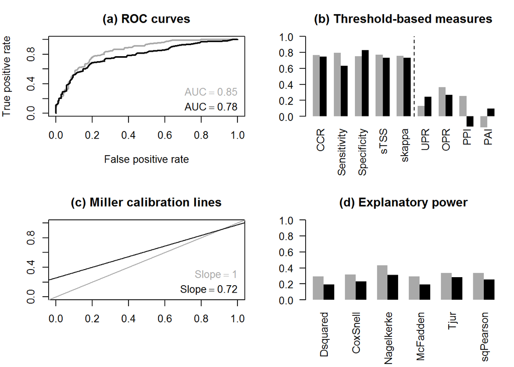

```r
# set plotting layout and margins:
par(mfrow = c(2, 2), mar = c(5.5, 4, 3, 1))

# ROC curves and AUC:
with(auc_train, plot(thresholds$sensitivity ~ thresholds$false.pos.rate, type = "l", lwd = 2, col = "darkgrey", xlab = "False positive rate", ylab = "True positive rate", main = "(a) ROC curves"))
with(auc_test, lines(thresholds$sensitivity ~ thresholds$false.pos.rate, lwd = 2, col = "black"))
text(1, 0.3, adj = 1, substitute(paste(AUC == a), list(a = round(auc_train$AUC, 2))), col = "darkgrey")
text(1, 0.1, adj = 1, substitute(paste(AUC == a), list(a = round(auc_test$AUC, 2))), col = "black")

# threshold-based measures barplot:
barplot(cbind(t(classif), t(misclass)), beside = T, las = 2, main = "(b) Threshold-based measures", col = c("darkgrey", "black"), border = rep(NA, 2), ylim = c(0, 1))
abline(v = 15.5, lty = 2)

# Miller calibration lines:
plot(c(0, 1), c(0, 1), type = "n", xlab = "", ylab = "", main = "(c) Miller calibration lines")
abline(a = miller_train$intercept, b = miller_train$slope, col = "darkgrey")
abline(a = miller_test$intercept, b = miller_test$slope, col = "black")
text(1, 0.3, adj = 1, substitute(paste(Slope == a), list(a = round(miller_train$slope, 2))), col = "darkgrey")
text(1, 0.1, adj = 1, substitute(paste(Slope == a), list(a = round(miller_test$slope, 2))), col = "black")

# explanatory power barplot:
barplot(t(explan), beside = T, las = 2, main = "(d) Explanatory power", col = c("darkgrey", "black"), border = rep(NA, 2), ylim = c(0, 1))
```

Note that these examples are based on limited distribution data (see `help(rotif.mods)`) and on fake test data. Hopefully you can get better results with your real data, such as the ones in the article that accompanies this guide (see beginning). This guide was built with *RStudio* + *rmarkdown* + *knitr*. Thanks!